# **Midterm Report**

## Introduction/Background:

With basketball being a popular pastime in the United States, fans spend much time on supplementary activities such as betting. Sports betting allows fans to engage at a deeper level - leading them to wager money and track stats, storylines, and performances at a game-by-game level.

The team plans to explore applications of machine learning to sports betting as it relates to the NBA season. Similar efforts in the past have successfully combined machine learning concepts such as convolutional neural networks with modern portfolio theory to maximize predictive power, as well as expected profit on NBA betting (Hubáček, 2019). Other examples in sports such as tennis have seen the use of ensemble methods incorporating models such as logistic regression, neural networks, random forests, GBM, and SVM maximize expected return (Wilkens, 2021).

The dataset that we will use consists of data from each of the regular and postseason NBA games from the 2007-2008 to the 2021-2022 seasons (Skompinski, 2021). For each game, there are several attributes (100+) involving statistics for each of the teams playing, in addition to some betting data.

## Problem Definition:

One of the most common forms of sports betting is on the winner of a given matchup. Their simplicity and frequency drives popularity among bettors. Therefore, we considered analyzing winners of individual matches throughout the season.

While predicting regular season wins would be a useful tool, we find it more compelling to make forecasts on the winners of playoff matchups, based on regular season data. Teams are often criticized for being “regular season” performers - lacking an “intangible” gear to go into when the heightened postseason atmosphere materializes. More attention and prominence is associated with betting in the playoffs, and oftentimes greater payouts - further solidifying the exercise as a worthwhile one.

## Methods:

Using our aforementioned NBA game data, we plan on using multiple methods in order to build our predictive model. Namely, we will create a convolutional neural network and use a brute force strategy in order to analyze statistics from previous matches and generate a prediction. Additionally, we want to approach the data with PCA (Preprocessing Analysis) in order to find metrics for optimal predicted value for game winners. We may also experiment with player datasets in order to refine the model

```python
# imports
import numpy as np
import pandas as pd
from tensorflow.keras import datasets, layers, models, losses
import matplotlib.pyplot as plt
from sklearn import preprocessing, decomposition, metrics
from sklearn.metrics import accuracy_score, mean_squared_error, roc_curve, roc_auc_score
```

```python
# Load the data that NBA games from the 2007-2008 to 2021-2022 seasons
df = pd.read_csv('DatasetFinal.csv')
df
```

|  | Unnamed: 0.1 | Unnamed: 0 | Post-Season | TEAM_NAME | GP | W | L | W_PCT | MIN | FGM | ... | BLKA_RANK.1 | PF_RANK.1 | PFD_RANK.1 | PTS_RANK.1 | PLUS_MINUS_RANK.1 | Date.1 | Score | Home-Team-Win | OU | OU-Cover |
| --- | --- | --- | --- | --- | --- | --- | --- | --- | --- | --- | --- | --- | --- | --- | --- | --- | --- | --- | --- | --- | --- |
| 0 | 0 | 0 | 0 | Philadelphia 76ers | 2 | 1 | 1 | 0.500 | 48.0 | 36.5 | ... | 7 | 24 | 9 | 28 | 27 | 2007-11-03 | 181 | 0 | 186.5 | 0 |
| 1 | 1 | 1 | 0 | Washington Wizards | 2 | 0 | 2 | 0.000 | 50.5 | 32.0 | ... | 13 | 10 | 6 | 19 | 16 | 2007-11-03 | 176 | 0 | 199.0 | 0 |
| 2 | 2 | 2 | 0 | Memphis Grizzlies | 1 | 0 | 1 | 0.000 | 48.0 | 38.0 | ... | 22 | 22 | 15 | 10 | 11 | 2007-11-03 | 232 | 0 | 211.5 | 1 |
| 3 | 3 | 3 | 0 | Milwaukee Bucks | 2 | 0 | 2 | 0.000 | 48.0 | 37.5 | ... | 20 | 24 | 4 | 23 | 23 | 2007-11-03 | 150 | 1 | 193.5 | 0 |
| 4 | 4 | 4 | 0 | Houston Rockets | 2 | 2 | 0 | 1.000 | 48.0 | 36.5 | ... | 5 | 2 | 22 | 22 | 28 | 2007-11-03 | 169 | 1 | 203.5 | 0 |
| ... | ... | ... | ... | ... | ... | ... | ... | ... | ... | ... | ... | ... | ... | ... | ... | ... | ... | ... | ... | ... | ... |
| 18838 | 18838 | 18838 | 1 | Golden State Warriors | 82 | 53 | 29 | 0.646 | 48.1 | 40.5 | ... | 11 | 5 | 20 | 12 | 2 | 2022-06-06 | 195 | 1 | 212.5 | 0 |
| 18839 | 18839 | 18839 | 1 | Boston Celtics | 82 | 51 | 31 | 0.622 | 48.5 | 40.7 | ... | 2 | 27 | 29 | 15 | 5 | 2022-06-08 | 216 | 1 | 212.5 | 1 |
| 18840 | 18840 | 18840 | 1 | Boston Celtics | 82 | 51 | 31 | 0.622 | 48.5 | 40.7 | ... | 2 | 27 | 29 | 15 | 5 | 2022-06-10 | 204 | 0 | 212.5 | 0 |
| 18841 | 18841 | 18841 | 1 | Golden State Warriors | 82 | 53 | 29 | 0.646 | 48.1 | 40.5 | ... | 11 | 5 | 20 | 12 | 2 | 2022-06-13 | 198 | 1 | 212.5 | 0 |
| 18842 | 18842 | 18842 | 1 | Boston Celtics | 82 | 51 | 31 | 0.622 | 48.5 | 40.7 | ... | 2 | 27 | 29 | 15 | 5 | 2022-06-16 | 193 | 0 | 212.5 | 0 |

18843 rows × 115 columns

### Data cleaning

In order to clean our data, we made several modifications. As the table includes game data from the 2007-2008 to the 2021-2022 NBA season across both regular season and playoff matchups, there are nearly 20,000 rows including over 100 fields. Save for the last four columns, most fields appear in duplicate - this is because they are shown for both teams (e.g., GP - Games Played, FGM - Field Goals Made, REB - Rebounds, etc.).

In order to distinguish between fields corresponding to the home team versus the away team, we concatenate a “.1” to the last 54 fields to designate the away team. While our dataset is relatively robust, we did see an opportunity to introduce some labels: namely, a binary “playoff” field.. However, the distinction between playoff and regular season games is not made clear in the data, so we introduced this column to the dataset. Additionally, we find it potentially valuable to add win/loss streak field(s) to demonstrate the effect of momentum on a team’s success. We have not yet implemented this attribute, but plan to for the final iteration.

```python
df.columns
df.drop(columns=df.columns[0:2],inplace=True)

# exclude dates
df = df.drop(columns=['Date.1', 'Date'])

# encoding the team names
enc = preprocessing.LabelEncoder()
df[['TEAM_NAME', 'TEAM_NAME.1']] = df[['TEAM_NAME', 'TEAM_NAME.1']].apply(enc.fit_transform)
df
```

|  | Post-Season | TEAM_NAME | GP | W | L | W_PCT | MIN | FGM | FGA | FG_PCT | ... | BLK_RANK.1 | BLKA_RANK.1 | PF_RANK.1 | PFD_RANK.1 | PTS_RANK.1 | PLUS_MINUS_RANK.1 | Score | Home-Team-Win | OU | OU-Cover |
| --- | --- | --- | --- | --- | --- | --- | --- | --- | --- | --- | --- | --- | --- | --- | --- | --- | --- | --- | --- | --- | --- |
| 0 | 0 | 26 | 2 | 1 | 1 | 0.500 | 48.0 | 36.5 | 82.5 | 0.442 | ... | 7 | 7 | 24 | 9 | 28 | 27 | 181 | 0 | 186.5 | 0 |
| 1 | 0 | 34 | 2 | 0 | 2 | 0.000 | 50.5 | 32.0 | 89.5 | 0.358 | ... | 15 | 13 | 10 | 6 | 19 | 16 | 176 | 0 | 199.0 | 0 |
| 2 | 0 | 16 | 1 | 0 | 1 | 0.000 | 48.0 | 38.0 | 80.0 | 0.475 | ... | 1 | 22 | 22 | 15 | 10 | 11 | 232 | 0 | 211.5 | 1 |
| 3 | 0 | 18 | 2 | 0 | 2 | 0.000 | 48.0 | 37.5 | 87.0 | 0.431 | ... | 19 | 20 | 24 | 4 | 23 | 23 | 150 | 1 | 193.5 | 0 |
| 4 | 0 | 11 | 2 | 2 | 0 | 1.000 | 48.0 | 36.5 | 77.0 | 0.474 | ... | 29 | 5 | 2 | 22 | 22 | 28 | 169 | 1 | 203.5 | 0 |
| ... | ... | ... | ... | ... | ... | ... | ... | ... | ... | ... | ... | ... | ... | ... | ... | ... | ... | ... | ... | ... | ... |
| 18838 | 1 | 10 | 82 | 53 | 29 | 0.646 | 48.1 | 40.5 | 86.4 | 0.469 | ... | 2 | 11 | 5 | 20 | 12 | 2 | 195 | 1 | 212.5 | 0 |
| 18839 | 1 | 1 | 82 | 51 | 31 | 0.622 | 48.5 | 40.7 | 87.4 | 0.466 | ... | 18 | 2 | 27 | 29 | 15 | 5 | 216 | 1 | 212.5 | 1 |
| 18840 | 1 | 1 | 82 | 51 | 31 | 0.622 | 48.5 | 40.7 | 87.4 | 0.466 | ... | 18 | 2 | 27 | 29 | 15 | 5 | 204 | 0 | 212.5 | 0 |
| 18841 | 1 | 10 | 82 | 53 | 29 | 0.646 | 48.1 | 40.5 | 86.4 | 0.469 | ... | 2 | 11 | 5 | 20 | 12 | 2 | 198 | 1 | 212.5 | 0 |
| 18842 | 1 | 1 | 82 | 51 | 31 | 0.622 | 48.5 | 40.7 | 87.4 | 0.466 | ... | 18 | 2 | 27 | 29 | 15 | 5 | 193 | 0 | 212.5 | 0 |

18843 rows × 111 columns

In order to set up the PCA, we needed to further preprocess our data. To do so, we standardized the data outside of the encoded team name using the scikit-learn StandardScaler() method, which calculates a z-score to normalize each value.

```python
# standardize the data
scaler = preprocessing.StandardScaler()
df.loc[:, ~df.columns.isin(['TEAM_NAME', 'TEAM_NAME.1', 'Home-Team-Win'])] = scaler.fit_transform(df.loc[:, ~df.columns.isin(['TEAM_NAME', 'TEAM_NAME.1', 'Home-Team-Win'])])
pd.set_option('display.max_columns', None)
df
```

|  | Post-Season | TEAM_NAME | GP | W | L | W_PCT | MIN | FGM | FGA | FG_PCT | FG3M | FG3A | FG3_PCT | FTM | FTA | FT_PCT | OREB | DREB | REB | AST | TOV | STL | BLK | BLKA | PF | PFD | PTS | PLUS_MINUS | GP_RANK | … |
| --- | --- | --- | --- | --- | --- | --- | --- | --- | --- | --- | --- | --- | --- | --- | --- | --- | --- | --- | --- | --- | --- | --- | --- | --- | --- | --- | --- | --- | --- | --- |
| 0 | -0.237112 | 26 | -1.684315 | -1.368008 | -1.466677 | -0.046255 | -1.011219 | -0.707016 | -0.407518 | -0.621131 | -1.672326 | -1.394144 | -2.349628 | 0.709227 | 1.694739 | -2.152713 | 3.942970 | 0.567243 | 2.841209 | -0.920818 | 3.053921 | -1.523315 | 3.192008 | 0.619164 | -0.658358 | 0.447442 | -0.929743 | 0.136055 | -1.141731 | … |
| 1 | -0.237112 | 34 | -1.684315 | -1.432666 | -1.391912 | -2.758043 | 6.490512 | -2.532929 | 1.278868 | -4.872798 | -2.026456 | -0.863886 | -6.426255 | 4.981527 | 5.535196 | -0.664518 | 5.290768 | -0.233890 | 2.841209 | -3.745270 | 3.053921 | -1.523315 | 0.560961 | 1.171527 | 3.166770 | 4.446446 | -0.929743 | -2.702999 | -1.141731 | … |
| 2 | -0.237112 | 16 | -1.725624 | -1.432666 | -1.466677 | -2.758043 | -1.011219 | -0.098379 | -1.009799 | 1.049166 | 0.452448 | -0.201062 | 2.754719 | -1.213308 | -1.143860 | -0.333808 | -3.132971 | 1.368377 | -0.481454 | -0.517325 | -0.424970 | -2.438365 | 1.087170 | 0.066801 | -0.931581 | -2.123346 | -0.290332 | -0.596604 | 1.337486 | … |
| 3 | -0.237112 | 18 | -1.684315 | -1.432666 | -1.391912 | -2.758043 | -1.011219 | -0.301258 | 0.676587 | -1.177897 | -1.495262 | -1.261579 | -1.870025 | -2.708613 | -1.811765 | -3.392875 | 3.606020 | -1.035024 | 1.082152 | -1.727804 | 1.662365 | -1.980840 | 1.087170 | 3.380980 | 5.079334 | 1.018729 | -1.711245 | -2.061923 | -1.141731 | … |
| 4 | -0.237112 | 11 | -1.684315 | -1.303349 | -1.541443 | 2.665533 | -1.011219 | -0.707016 | -1.732535 | 0.998551 | -1.141133 | -0.731321 | -2.246856 | 1.777302 | 2.362645 | -1.133024 | -0.100425 | 0.767527 | 0.691250 | -0.517325 | 1.314475 | 1.679359 | 1.613380 | -1.590289 | 3.439994 | 2.161301 | -0.361378 | 1.143461 | -1.141731 | … |
| ... | ... | ... | ... | ... | ... | ... | ... | ... | ... | ... | ... | ... | ... | ... | ... | ... | ... | ... | ... | ... | ... | ... | ... | ... | ... | ... | ... | ... | ... | … |
| 18838 | 4.217421 | 10 | 1.620342 | 1.994246 | 0.626761 | 0.745587 | -0.711150 | 0.916017 | 0.532040 | 0.745476 | 1.975203 | 1.972998 | 0.322446 | -0.956970 | -1.043674 | 0.189816 | -0.572154 | 1.248207 | 0.886701 | 1.943984 | 0.201230 | 1.038824 | -0.491458 | -1.148398 | 0.161312 | -1.552059 | 1.130581 | 0.960297 | -1.254422 | … |
| 18839 | 4.217421 | 1 | 1.620342 | 1.864929 | 0.776292 | 0.615421 | 0.489127 | 0.997169 | 0.772952 | 0.593631 | 1.585661 | 1.668099 | 0.048387 | -0.358848 | -0.843302 | 1.485097 | -0.100425 | 1.168094 | 1.121242 | 1.015949 | -0.703281 | -0.425255 | 0.876686 | -0.375090 | -1.204805 | -0.752259 | 1.244254 | 1.289993 | -1.254422 | … |
| 18840 | 4.217421 | 1 | 1.620342 | 1.864929 | 0.776292 | 0.615421 | 0.489127 | 0.997169 | 0.772952 | 0.593631 | 1.585661 | 1.668099 | 0.048387 | -0.358848 | -0.843302 | 1.485097 | -0.100425 | 1.168094 | 1.121242 | 1.015949 | -0.703281 | -0.425255 | 0.876686 | -0.375090 | -1.204805 | -0.752259 | 1.244254 | 1.289993 | -1.254422 | … |
| 18841 | 4.217421 | 10 | 1.620342 | 1.994246 | 0.626761 | 0.745587 | -0.711150 | 0.916017 | 0.532040 | 0.745476 | 1.975203 | 1.972998 | 0.322446 | -0.956970 | -1.043674 | 0.189816 | -0.572154 | 1.248207 | 0.886701 | 1.943984 | 0.201230 | 1.038824 | -0.491458 | -1.148398 | 0.161312 | -1.552059 | 1.130581 | 0.960297 | -1.254422 | … |
| 18842 | 4.217421 | 1 | 1.620342 | 1.864929 | 0.776292 | 0.615421 | 0.489127 | 0.997169 | 0.772952 | 0.593631 | 1.585661 | 1.668099 | 0.048387 | -0.358848 | -0.843302 | 1.485097 | -0.100425 | 1.168094 | 1.121242 | 1.015949 | -0.703281 | -0.425255 | 0.876686 | -0.375090 | -1.204805 | -0.752259 | 1.244254 | 1.289993 | -1.254422 | … |

18843 rows × 111 columns

### Pre-Processing

To conduct PCA, we drop five columns (Team_Name, Team_Name.1, Score, Home-Team-Win, and OU-Cover). We set our variance threshold to 95%, and using scikit-learn’s PCA object, we fit_transform our dataset to 39 principal components. Next, a boolean variable do_PCA is set to decide if we want to include PCA components or our raw components in model training. This is useful for comparing model performance between with and without PCA.

```python
# PCA but exclude the categorical team
df_PCA = df.drop(columns=['TEAM_NAME', 'TEAM_NAME.1', 'Score', 'OU-Cover', 'Home-Team-Win'])
pca = decomposition.PCA(n_components=0.95)
df_PCA_transformed = pca.fit_transform(df_PCA)
print(f'Below is an array of the new components sorted by decreasing explained variance:')
print(pca.explained_variance_ratio_)
print(f'New # of features is: {len(pca.explained_variance_ratio_)}')
print(df_PCA_transformed.shape[1])
```

```
Below is an array of the new components sorted by decreasing explained variance:
[0.12745512 0.10076323 0.07608993 0.06206797 0.05468607 0.04432613
 0.03973272 0.03345278 0.03167167 0.0287499  0.02576062 0.02246284
 0.02151666 0.02089517 0.02027327 0.01907206 0.01722817 0.01660381
 0.01489936 0.01403583 0.01386167 0.01370157 0.01260842 0.01218534
 0.01137468 0.0110126  0.01043711 0.00881364 0.00833028 0.0079119
 0.00739717 0.00706714 0.0062544  0.00597844 0.00582031 0.00569525
 0.00500508 0.00404083 0.00350045]
New # of features is: 39
39
```

```python
do_PCA = False

if do_PCA:
    arr = np.array(df_PCA_transformed)
    labels = np.array(df['Home-Team-Win']).reshape((-1, 1))
    arr = np.hstack((arr, labels))
else:
    arr = np.array(df_PCA)
    labels = np.array(df['Home-Team-Win']).reshape((-1, 1))
    arr = np.hstack((arr, labels))
# labels added to the end
arr[:5, -5:]
```

[output not shown]

```python
# randomize data based on dates
rand = arr.copy()
np.random.shuffle(rand)
rand
```

[output not shown]

### Model Design

```python
# remove y label (home team winning)
y = rand[:, -1]
x = np.delete(rand, -1, axis=1)

# take a % of data for training
percent = 0.90
length = len(rand)
x_train = x[:int(percent * length), :]
y_train = y[:int(percent * length)]
x_test = x[int(percent * length):, :]
y_test = y[int(percent * length):]
```

```python
x_train.shape
```

```
(16958, 106)
```

```python
# basic neural net to see if it works
model = models.Sequential([
    layers.Dense(units=100, activation='relu', input_shape=(x_train.shape[1], )),
    layers.Dense(units=1, activation='sigmoid')
])
model.summary()
```

[output not shown]

```python
model.compile(optimizer='adam', loss='binary_crossentropy', metrics=['acc'])
losses_data = model.fit(x_train, y_train, validation_data = (x_test, y_test), epochs=40)
```

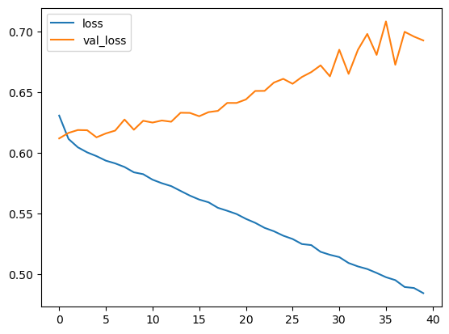

```python
loss = pd.DataFrame(losses_data.history)
loss
loss.loc[:, ['loss', 'val_loss']].plot()
```

```
Confusion Matrix:
 [[411 398]
 [249 827]]
F1 Score: 0.72
Accuracy: 0.66
MSE: 0.34
AUC: 0.69
```

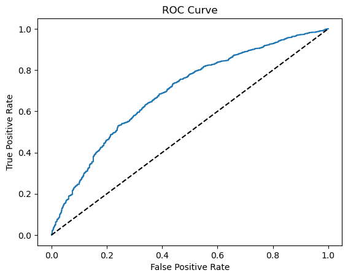

```python
# Calculating F1 score
pred = model.predict(x_test)
binary_pred = (pred > 0.5).astype(np.float32)

conmat = metrics.confusion_matrix(y_test, binary_pred)
print("Confusion Matrix:\n", conmat)

# do accuracy, confusion matrix, F1 score

f1 = metrics.f1_score(y_test, binary_pred)
print("F1 Score: {:.2f}".format(f1))

acc = accuracy_score(y_test, binary_pred)

print("Accuracy: {:.2f}".format(acc))

mse = mean_squared_error(y_test, binary_pred)

print("MSE: {:.2f}".format(mse))

# generate ROC curve
fpr, tpr, thresholds = roc_curve(y_test, pred)

# calculate AUC
auc = roc_auc_score(y_test, pred)

print("AUC: {:.2f}".format(auc))

# plot ROC curve
plt.plot(fpr, tpr)
plt.plot([0, 1], [0, 1], 'k--')
plt.xlabel('False Positive Rate')
plt.ylabel('True Positive Rate')
plt.title('ROC Curve')
plt.show()
```

## Team Contribution

A contribution table below shows all team members' names that explicitly provides the contribution of each member in preparing the project proposal.

| Name | Introduction | Problem Definition | Method | Collect Dataset | Result & Discussion | Github Page |
| --- | --- | --- | --- | --- | --- | --- |
| Spencer Kim | ✔️ | ✔️ | ✔️ | ✔️ | ✔️ |  |
| Alfonso Garcia | ✔️ | ✔️ | ✔️ | ✔️ | ✔️ |  |
| Brett Graybill | ✔️ | ✔️ | ✔️ | ✔️ | ✔️ |  |
| Seungmi Lee |  |  |  |  | ✔️ | ✔️ |
| Rohan Misra | ✔️ | ✔️ | ✔️ | ✔️ | ✔️ |  |